# Regressions

Yilun

5/17/2021

Let us take a quick look at the distribution of weights and compute summary statistics:

```r
hist(Auto$weight, xlab = "weight", col = "blue");grid()
(weightSum = summary(Auto$weight))
```

```
##    Min. 1st Qu.  Median    Mean 3rd Qu.    Max.
##    1613    2225    2804    2978    3615    5140
```

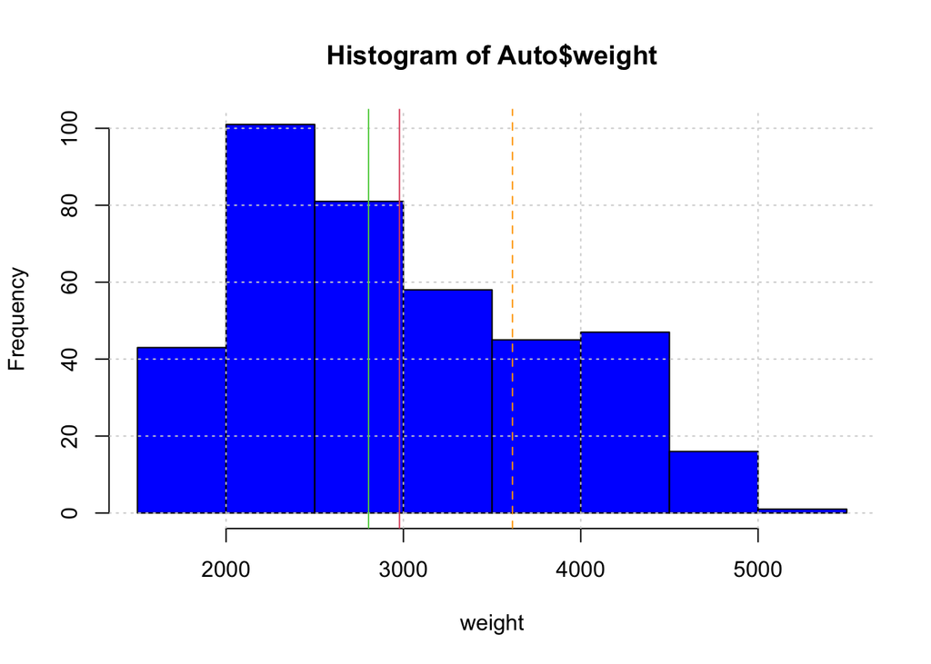

```r
abline(v=weightSum["Median"],col=3)
abline(v=weightSum["Mean"],col=2)
abline(v=weightSum["3rd Qu."],col="orange", lty=2)
```

We can see a marked difference between the mean and the median (why again?). That brings up the general question, how to choose from the various “location measures” of a distribution, such as the mean, median, trimmed mean, geometric mean, harmonic mean, …

## Loss Functions

Can we define an objective optimality measure which would clearly favor one metric over another ? Welcome to the concept of a **loss function**. We all feel intuitively that the orange line (at 3615 lb) is in some sense inferior to the red and green numbers as a location measure.

Why? Because the distance from the data to orange is (on the average) larger than the distance to red and green. Let us call that **average distance a “loss”** and assume that we want to **minimize loss**.

It turns out that there is not just one but various ways to define this distance/loss function (“LE” = location estimate):

1. Minimized by the **Modus**
   $$L_0 = (1/n) \cdot \sum_{i=1}^n{|x_i - LE|^0}$$
2. Minimized by the **Median**
   $$L_1 = (1/n) \cdot \sum_{i=1}^n{|x_i - LE|^1}$$
3. Minimized by the **Mean**
   $$L_2 = (1/n) \cdot \sum_{i=1}^n{|x_i - LE|^2}$$

## SLR

Simple Linear Regression (SLR)

Population Version:
$$y_i = \beta_0 + \beta_1 \cdot x_i + \epsilon_i$$
Sample Version (Estimated from data):
$$y_i = \hat{\beta}_0 + \hat{\beta}_1 \cdot x_i + \hat{\epsilon}_i = \hat{y}_i + \hat{\epsilon}_i$$

Loss Function = **residual sum of squares** (RSS) !

Minimizing $RSS = \sum_{i=1}^n{\hat{\epsilon}_i^2}$ leads to the following **Least Squares** coefficient estimates:

$$\begin{align}
\hat{\beta}_1 & = \frac{\sum_{i=1}^{n}{(x_i - \bar{x})(y_i - \bar{y})}}{\sum_{i=1}^{n}{(x_i - \bar{x})^2}} \label{eq:betaHat1} \\
\hat{\beta}_0 & = \bar{y} - \hat{\beta_1} \bar{x}
\end{align}$$

The first equation is simply the sample covariance between $x$ and $y$ divided by the sample variance of x: $\hat{\beta}_1 = cov_{xy}/var_x$. (why?)

## Regression Line

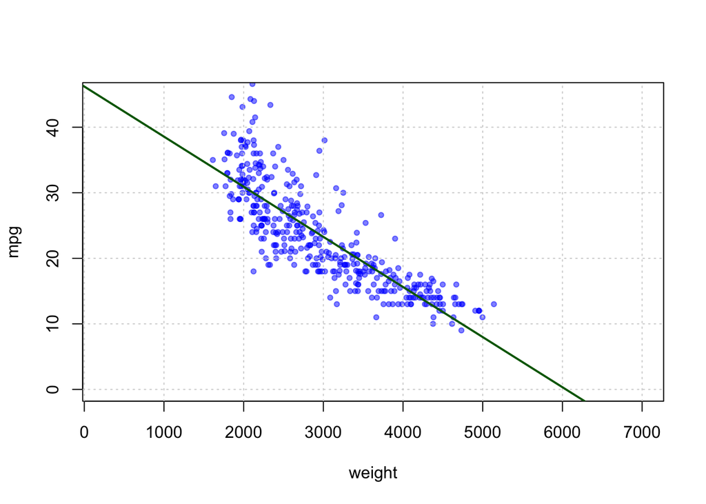

```r
plot(mpg ~ weight, data = Auto,col = rgb(0,0,1,0.5), pch=20,xlim=c(250, 7000), ylim = c(0,45));grid()
LSfit = lm(mpg ~ weight, data = Auto)

#overlay regression line
abline(LSfit, col="darkgreen",lwd=2)
```

```r
#summary
summary(LSfit)
```

```
##
## Call:
## lm(formula = mpg ~ weight, data = Auto)
##
## Residuals:
##      Min       1Q   Median       3Q      Max
## -11.9736  -2.7556  -0.3358   2.1379  16.5194
##
## Coefficients:
##              Estimate Std. Error t value Pr(>|t|)
## (Intercept) 46.216524   0.798673   57.87   <2e-16 ***
## weight      -0.007647   0.000258  -29.64   <2e-16 ***
## ---
## Signif. codes:  0 '***' 0.001 '**' 0.01 '*' 0.05 '.' 0.1 ' ' 1
##
## Residual standard error: 4.333 on 390 degrees of freedom
## Multiple R-squared:  0.6926, Adjusted R-squared:  0.6918
## F-statistic: 878.8 on 1 and 390 DF,  p-value: < 2.2e-16
```

```r
#diagnostics
#plot(LSfit, c(1,2,5))
```

- Use the correlation coefficient to compute the slope.
- Interpret the slope, precisely.

If we increase the weight by one unit the average mpg decreases by 0.007 units.

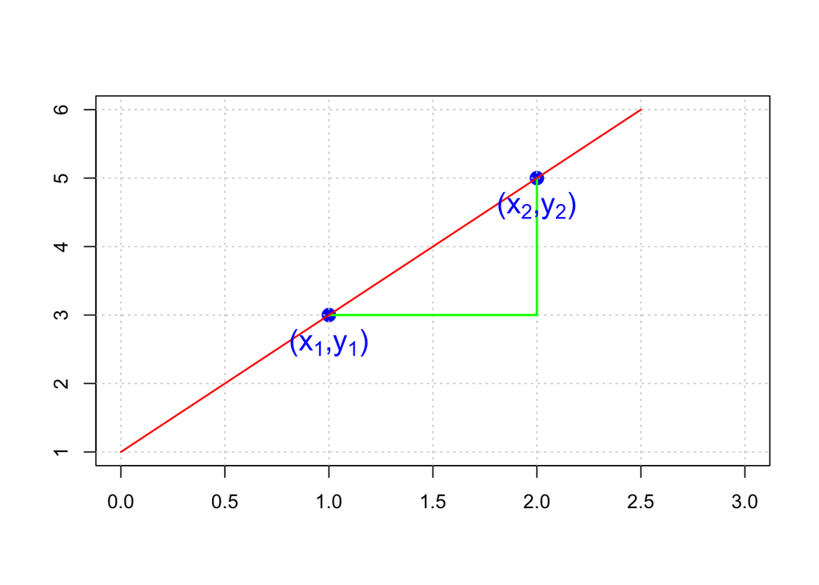

$$\beta_1 = \frac{\Delta y}{\Delta x} = \frac{y_2-y_1}{x_2-x_1}$$

## Exercise 17 May

### Residuals

- Verify that the sum of the residuals is zero
- Verify the **Least Squares Property** of the regression line.

```r
# Verify sum of residual is zero
Auto %>%
  summarise(residual = (LSfit$coefficients[2]* weight + LSfit$coefficients[1])- mpg)%>%
  sum()
```

```
## [1] 4.24194e-12
```

### $R^2$

- Compute $R^2$ using two different expressions:
  - $R^2 = r^2$
  - $R^2 = 1 - RSS/TSS$

```r
#Method 1
cor(Auto$weight,Auto$mpg)^2
```

```
## [1] 0.6926304
```

```r
#Method 2
RSS = sum(LSfit$residuals^2)
TSS = sum((Auto$mpg-mean(Auto$mpg))^2)

1-(RSS/TSS)
```

```
## [1] 0.6926304
```